# Reproducible Research: Peer Assessment 1

Catherine Pfeifer

Febuary 2018

# Reproducible Research: Peer Assessment 1

## objective of the assignement

This is the first assignment for the **Reproducible Research** course in Coursera’s Data Science specialization. The purpose of the project was to answer a series of questions using data collected from a [FitBit](http://en.wikipedia.org/wiki/Fitbit).

## Overview of the steps

- loading and preprocessing data
- imputing missing values
- interpreting data to answer research questions

The objective of this output is to document the process that has led the results

## Data

The data for this assignment was downloaded from the web:

- Dataset: [Activity monitoring data](https://d396qusza40orc.cloudfront.net/repdata%2Fdata%2Factivity.zip) [52K]

The variables included in this dataset are:

- **steps**: Number of steps taking in a 5-minute interval (missing values are coded as `NA`)
- **date**: The date on which the measurement was taken in YYYY-MM-DD format
- **interval**: Identifier for the 5-minute interval in which measurement was taken

The dataset is stored in a comma-separated-value (CSV) file and there are a total of 17,568 observations in this dataset.

# Results

## Loading and preprocessing the data

load all necessary libraries

```r
library(dplyr)
```

```r
library(ggplot2)
```

Download, unzip and load data into data frame data.

```r
if(!file.exists("getdata-projectfiles-UCI HAR Dataset.zip")) {
        temp <- tempfile()
        download.file("http://d396qusza40orc.cloudfront.net/repdata%2Fdata%2Factivity.zip",temp)
        unzip(temp)
        unlink(temp)
}

data <- read.csv("activity.csv")
summary(data)
```

```
##      steps                date          interval
##  Min.   :  0.00   2012-10-01:  288   Min.   :   0.0
##  1st Qu.:  0.00   2012-10-02:  288   1st Qu.: 588.8
##  Median :  0.00   2012-10-03:  288   Median :1177.5
##  Mean   : 37.38   2012-10-04:  288   Mean   :1177.5
##  3rd Qu.: 12.00   2012-10-05:  288   3rd Qu.:1766.2
##  Max.   :806.00   2012-10-06:  288   Max.   :2355.0
##  NA's   :2304     (Other)   :15840
```

We have 3 variables of which date is a factor, so we first need to transform it into a date format and get the names of the day

```r
data$day <- weekdays(as.Date(data$date))
data$date<- as.POSIXct(data$date, format="%Y-%m-%d")
data$day<-weekdays(data$date)
```

## What is mean total number of steps taken per day?

So we need to aggregate ber date, we use dplyr package

```r
steps <- data %>%filter(!is.na(steps)) %>%  group_by(date) %>%  summarize(steps = sum(steps))
  head (steps)
```

```
## # A tibble: 6 x 2
##         date steps
##       <dttm> <int>
## 1 2012-10-02   126
## 2 2012-10-03 11352
## 3 2012-10-04 12116
## 4 2012-10-05 13294
## 5 2012-10-06 15420
## 6 2012-10-07 11015
```

Here is the histogram of the sum of the step per day :

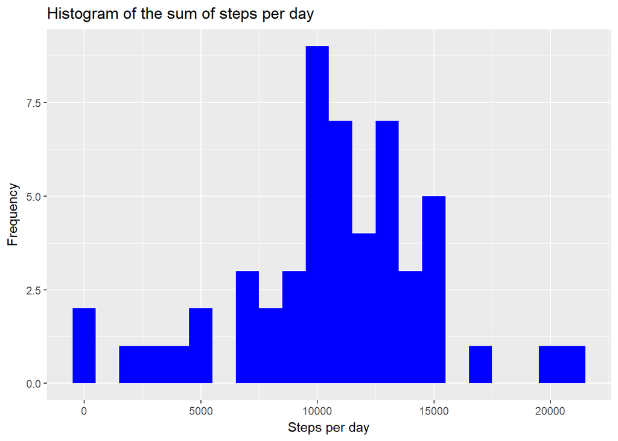

```r
ggplot(steps, aes(x = steps)) +
  geom_histogram(fill = "blue", binwidth = 1000) +
  labs(title = "Histogram of the sum of steps per day", x = "Steps per day", y = "Frequency")
```

Here are the mean and median of the sum of step by day

```r
summary(steps$steps)
```

```
##    Min. 1st Qu.  Median    Mean 3rd Qu.    Max.
##      41    8841   10765   10766   13294   21194
```

## What is the average daily activity pattern?

To answer this question we first we need to make a time series with the interval

```r
interval <- data %>%  filter(!is.na(steps)) %>%  group_by(interval) %>%  summarize(steps = mean(steps))
```

This results in an average setp per interval

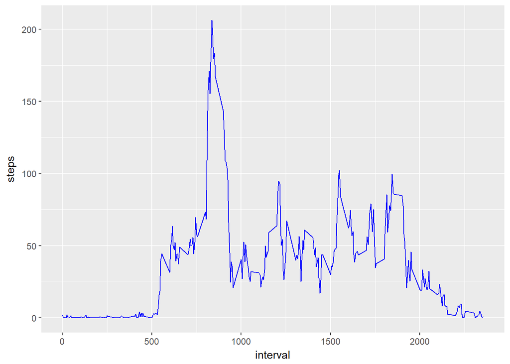

```r
ggplot(interval, aes(x=interval, y=steps)) +
  geom_line(color = "blue")
```

To get the maximum steps, on average, across all the days, we can use the **which.max()** function

```r
interval[which.max(interval$steps),]
```

```
## # A tibble: 1 x 2
##   interval    steps
##      <int>    <dbl>
## 1      835 206.1698
```

## Imputing missing values

Note that there are a number of days/intervals where there are missing values (coded as NA). The presence of missing days may introduce bias into some calculations or summaries of the data.

### Calculate and report the total number of missing values in the dataset

```r
summary(is.na(data$steps))
```

```
##    Mode   FALSE    TRUE
## logical   15264    2304
```

So we have 2304 missing values

### Devise a strategy for filling in all of the missing values in the dataset.

Let’s aim at replacing with the average number of steps in the same 5-min interval in a given day.

Create the average table with an identifier that identifies the interval and the day of the week

```r
avgTable <- data %>%filter(!is.na(steps)) %>% group_by(interval, day) %>% summarize( Avg = mean(steps))%>%mutate(iid=paste0(interval,day))
head(avgTable)
```

```
## # A tibble: 6 x 4
## # Groups:   interval [1]
##   interval      day      Avg       iid
##      <int>    <chr>    <dbl>     <chr>
## 1        0   Friday 0.000000   0Friday
## 2        0   Monday 1.428571   0Monday
## 3        0 Saturday 0.000000 0Saturday
## 4        0   Sunday 0.000000   0Sunday
## 5        0 Thursday 5.875000 0Thursday
## 6        0  Tuesday 0.000000  0Tuesday
```

### replace the NA based on the iid (interval day identifier)

```r
data$iid<-paste0(data$interval,data$day)
data$steps[is.na(data$steps)]<-avgTable$Avg[match(data$iid[is.na(data$steps)],avgTable$iid)]
summary(data$steps)
```

```
##    Min. 1st Qu.  Median    Mean 3rd Qu.    Max.
##    0.00    0.00    0.00   37.57   19.04  806.00
```

We see now there are no NA is steps anymore.

### reproduce graph and statistics with the new data that has no NAs

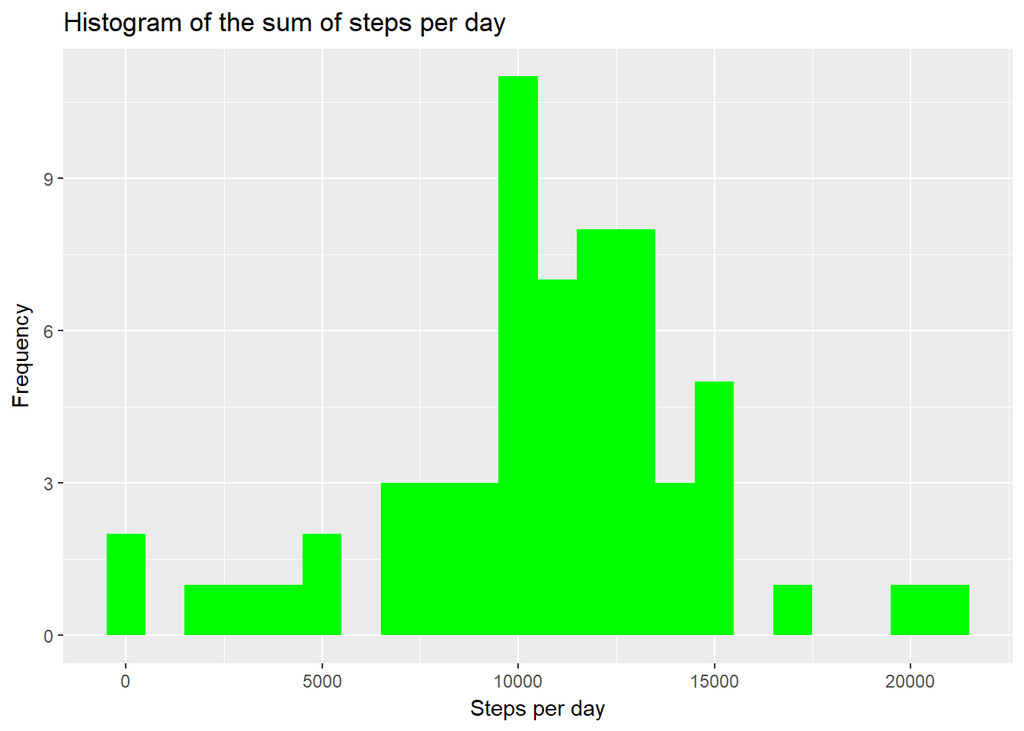

```r
steps <- data  %>%  group_by(date) %>%  summarize(steps = sum(steps))
ggplot(steps, aes(x = steps)) +
  geom_histogram(fill = "green", binwidth = 1000) +
  labs(title = "Histogram of the sum of steps per day", x = "Steps per day", y = "Frequency")
```

We can also get the new median and mean

```r
summary(steps$steps)
```

```
##    Min. 1st Qu.  Median    Mean 3rd Qu.    Max.
##      41    8918   11015   10821   12811   21194
```

## Are there differences in activity patterns between weekdays and weekends?

### create a variable that identifies weekends

```r
data <- mutate(data, weektype = ifelse(day == "Saturday" | day == "Sunday", "weekend", "weekday"))
head(data)
```

```
##      steps       date interval    day      iid weektype
## 1 1.428571 2012-10-01        0 Monday  0Monday  weekday
## 2 0.000000 2012-10-01        5 Monday  5Monday  weekday
## 3 0.000000 2012-10-01       10 Monday 10Monday  weekday
## 4 0.000000 2012-10-01       15 Monday 15Monday  weekday
## 5 0.000000 2012-10-01       20 Monday 20Monday  weekday
## 6 5.000000 2012-10-01       25 Monday 25Monday  weekday
```

### create table that summarize the average steps per interval split by weektypoe

```r
interval <- data %>%  group_by(interval, weektype) %>%  summarise(steps = mean(steps))
head(interval)
```

```
## # A tibble: 6 x 3
## # Groups:   interval [3]
##   interval weektype    steps
##      <int>    <chr>    <dbl>
## 1        0  weekday 2.310714
## 2        0  weekend 0.000000
## 3        5  weekday 0.450000
## 4        5  weekend 0.000000
## 5       10  weekday 0.175000
## 6       10  weekend 0.000000
```

### make a graph that allows to assess the differences between the weekday and weekend

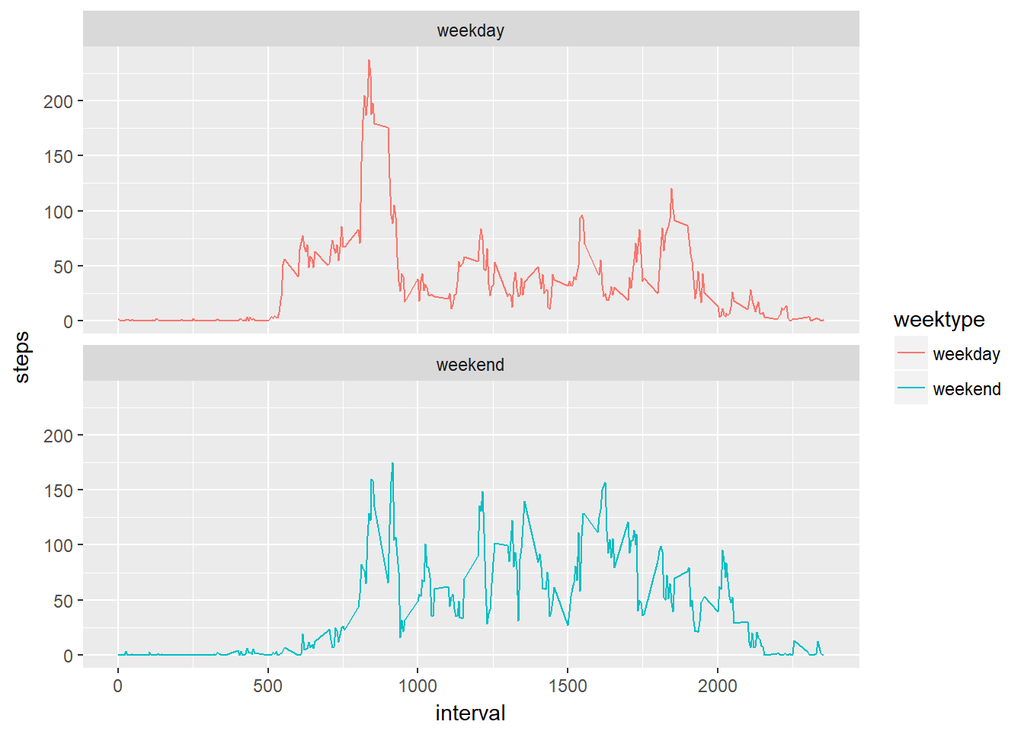

```r
g <- ggplot(interval, aes(x=interval, y=steps, color = weektype)) +
  geom_line() +
     facet_wrap(~weektype, ncol = 1, nrow=2)

print(g)
```

From the two plots it seems that the test object is more active earlier in the day during weekdays compared to weekends, but more active throughout the weekends compared with weekdays.